# Лабораторная работа №6. Задача об эпидемии

Вариант 38

Автор

принадлежность

Амина Накова

Российский университет дружбы народов

Аннотация

Рассматривается простейшая модель эпидемии (SIR). Популяция разделена на три группы: восприимчивые S(t), инфицированные I(t), выздоровевшие с иммунитетом R(t). Анализируются два случая: I(0) ≤ I* и I(0) > I*.

Ключевые слова

математическое моделирование, эпидемия, SIR, Julia

# 1 Введение

## 1.1 Актуальность

Модели эпидемий — классический раздел математической биологии и эпидемиологии. Они применяются для прогнозирования распространения инфекций и оценки мер контроля.

## 1.2 Цель работы

Построить графики изменения численностей трёх групп (S, I, R) для двух случаев: когда начальное число инфицированных не превышает критического значения I*, и когда превышает.

## 1.3 Задачи

1. Записать систему уравнений SIR-модели.
2. Решить её численно для двух случаев.
3. Построить графики S(t), I(t), R(t).
4. Проанализировать динамику эпидемии.

## 1.4 Методы исследования

Численное интегрирование методом `Tsit5()`, визуализация `Plots.jl`.

# 2 Теоретическая часть

## 2.1 Модель эпидемии

Популяция разбита на три группы: - $S(t)$ — восприимчивые, но пока здоровые; - $I(t)$ — инфицированные (распространители); - $R(t)$ — выздоровевшие с иммунитетом.

**Случай A (I(0) ≤ I*):** все больные изолированы. Уравнения:

$$\frac{dS}{dt} = 0, \quad \frac{dI}{dt} = -\beta I, \quad \frac{dR}{dt} = \beta I$$

**Случай B (I(0) > I*):** эпидемия развивается. Уравнения:

$$\frac{dS}{dt} = -\alpha S, \quad \frac{dI}{dt} = \alpha S - \beta I, \quad \frac{dR}{dt} = \beta I$$

где $\alpha$ — коэффициент заболеваемости, $\beta$ — коэффициент выздоровления.

# 3 Материалы и методы

Работа выполнена на языке Julia 1.13 с пакетами:

- `DifferentialEquations.jl`
- `Plots.jl`
- `DrWatson.jl`
- `Literate.jl`

## 3.1 Параметры варианта 38

- $N = 12700$, $I(0) = 170$, $R(0) = 57$
- $S(0) = N - I(0) - R(0) = 12473$
- $\alpha = 0.01$, $\beta = 0.02$, $I^* = 100$
- $t \in [0; 200]$

# 4 Выполнение лабораторной работы

## 4.1 Случай A: I(0) ≤ I*

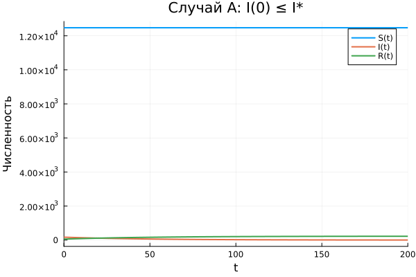

Рисунок 1: Случай A: I(0) ≤ I*

Число восприимчивых S(t) не меняется; инфицированные монотонно убывают (все изолированы и лечатся); выздоровевшие R(t) растут.

## 4.2 Случай B: I(0) > I*

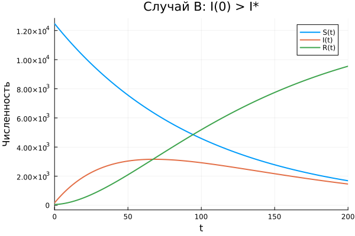

Рисунок 2: Случай B: I(0) > I*

Восприимчивые S(t) убывают, инфицированные I(t) сначала растут, затем достигают максимума и падают; выздоровевшие R(t) растут.

## 4.3 Сводный график

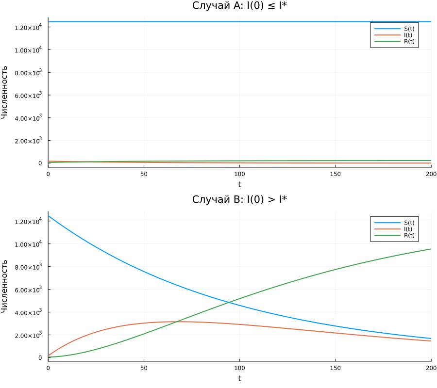

Рисунок 3: Сводный график

# 5 Результаты

# 6 Обсуждение результатов

# 7 Заключение

- Система SIR решена численно для двух случаев.
- Построены графики S(t), I(t), R(t).
- Проанализирована динамика эпидемии.

# Список литературы